# Logit/Probit Models

```r
#devtools::install_github("strengejacke/strengejacke")
```

So… you’ve got a binary dependent variable.

We’ve talked about LPM in our OLS discussion. So, I won’t review it here, but I will say` that LPM can be a great model to use - so logit/probit doesn’t have to be your default. What’s better is to show the LPM model along with logit probit. And frankly, I always do LPM first to get an intuitive basic understanding of what’s going on.

### Pros/Cons LPM

Pro: Using a linear model for a binary outcome is convenient because estimation is easy and so is interpretation.

Cons:

1. The fitted values from an OLS regression are never guaranteed to be between zero and one, yet these fitted values are estimated probabilities.
   - This can be slightly embarassing but is rarely a big deal. We usually use the LPM to estimate partial effects, not to make predictions.
   - Further, a natural predictor is not sensitive to negative fitted values or fitted values above one.
2. The estimated partial effects are constant throughout the range of the explanatory variables, possibly leading to silly estimated effects for large changes.
   - This is related to predicted probabilities possibly being negative or greater than one.

This is more of a problem because we know that, say, a variable with a positive effect on $P (y =1\vert \mathbf{x})$ must eventually have a diminishing effect. But the linear model implies a constant effect (when the variable appears by itself).

3. Because $y$ is binary – and this really has nothing to do with the LPM per se – the LPM must exhibit heteroskedasticity except in the one case where no $x_{j}$ affects $P (y =1\vert \mathbf{x})$. This follows because for a binary variable,

$$\begin{equation}V a r (y\vert
\mathbf{x}) =p (\mathbf{x})[1 -p(\mathbf{x})]
\end{equation}$$
where $p (\mathbf{x}) =\beta _{0} +\beta _{1} x_{1} +\beta _{2} x_{2} +\ldots +\beta _{k} x_{k}$ is the linear response probability.

This is a case where we **know** MLR.5 must fail, and we know how. So, currently, we treat the usual $t$ and $F$ tests with suspicion, and the confidence intervals. (Turns out they are often pretty reliable in LPMs.)

# Logit/Probit

A general model that ensures probabilities are between zero and one has the form
$$\begin{equation*}P (y =1\vert
\mathbf{x}) =G (\beta _{0} +\beta _{1} x_{1} +\beta _{2} x_{2}
+\ldots +\beta _{k} x_{k})
\end{equation*}$$
for some function $G$ that takes values between zero and one.

In most cases, $G ( \cdot )$ is actually a cumulative distribution function (cdf) for a continuous random variable with probability density function $g ( \cdot )$. Then, $G ( \cdot )$ is strictly increasing, and the estimates are easier to interpret.

The leading cases are

$$\begin{gather*}G (z) =\Lambda (z)
=\frac{\exp (z)}{[1 +\exp (z)]}\text{\ \ (logit)} \\
G (z) =\Phi (z) =\int _{ -\infty }^{z}\frac{1}{\sqrt{2 \pi }} \exp (
-u^{2}/2) d u\text{\ \ (probit)}\end{gather*}$$

These functions have similar shapes but the logistic is more spread out.

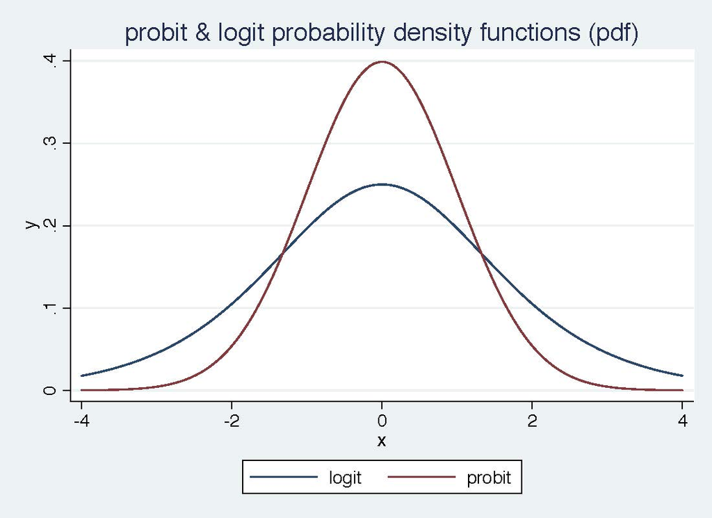

probit vs. logit

The estimation method for the $\beta _{j}$ is maximum likelihood.

(Asymptotic) standard errors are reported, as are $t$ statistics and confidence intervals.

T-tests and F-tests work the same.

### MLE Theory & Estimation

The PDF (probability distribution function) of $Y_i$ given $X_i$ is known *except* for only three parameters, $\beta_0, \beta_1, \sigma^2_u$:

$$\begin{equation}
f_{Y_i|X_i}(y) =
\frac{1}{\sqrt{2\pi\sigma^2_u}}exp(-\frac{1}{2\sigma^2_u}(Y_i - \beta_0
+ \beta_1X_i)^2)
\end{equation}$$

With the assumption of normality, we can use maximum liklihood estimation.

The basic idea is that we choose parameter estimates to maximize a measure of the likeliness of the sample outcomes - this is called the liklihood function. ML estimators of $\beta_0$ and $\beta_1$ are those values that $\hat{\beta_0}$ and $\hat{\beta_1}$ can best describe the full distribution of the data.

The liklihood function is the joint probability function of $Y_1$ conditional on $X_1$.

It’s *way* easier to deal with the log of some function - which we call a logliklihood function, where all we do is replace the hypothetical values and take the logs. Think about that exponential function in the pdf. If we take the log of an exponential - that makes the form easier to deal with (recall $y = b^x = log_b(y) = x$)

Fortunately, ML estimators is equivalent to maximizing the loglikelihood function.

You essentially set the derivatives of the logliklihood function equal to zero and solve for first-order conditions. This doesn’t provide a closed form formulate, and usually we use numerical methods that guess a number, solve for it and then take the second derivative to see if the slope is positive or negative and once it’s close to zero, you’ve found a solution. Hence, MLE has successive iterations.

What is nice about using MLE is that the variance is unbiased! When we use OLS - the variance is not unbiased. No where did we make that a requirement with our as sumption (indeed, $\beta_1$ is unbiased). So, MLE is incredibly *efficient* and our issue with multi-collinearity dissappears.

The properties of MLE are asymptotic - they are approximate in real-world samples - and as N gets larger, we know it will approximate to the true value.

This is a different *estimation* method. The model can be the same for OLS and MLE, but the estimation method is different. OLS minimized the sum of squares. MLE maximizes the liklihood funciton.

As a result, there is not $R^2$ in MLE. Instead, we use log-liklihood ratios - and that is basically an F-test!

So, here we are full-circle. The logliklihood ratio is:

$(\frac{SSR_u}{SSR_R})^{-n/2}$

where we compare our restricted model to our unrestricted model.

Note: this points out how estimation models that may have the same assumptions can have different properties - particularly, MLE is efficient because we can accurately estimate the variance of our estimator.

Why don’t we just use this all the time? Because the assumption of normality is too strict and we rarely it in the data wild.

To Summarize:

- ML maximises a measure of the likeliness of the sample outcomes called the likelihood function.
- ML picks the values of the parameters that best describe the distribution of the observed data.
- The sample mean is a ML estimator (MLE).
- Other estimation methods exist, but if the assumptions are satisfied, then the MLE has the smallest variance (most efficient, no other estimator is better).
- We maximize the (log) likelihood function or minimize the negative log likelihood. Probabilities are very small numbers! Logs of probabilities are large negative numbers!
- Parameter values are typically found using iterative Newton-Raphson steps based on numerical derivatives.

Given an independent and identically distributed (i.i.d.) sample, the joint density function is
$$f(Y_{1\ldots N} |
\boldsymbol\beta, \mathbf{X}_{1\ldots N}) = f(Y_1|\boldsymbol\beta,
\mathbf{X}_1)\times f(Y_2|\boldsymbol\beta, \mathbf{X}_2) \times \cdots
\times f(Y_N|\boldsymbol\beta, \mathbf{X}_N)$$
where $\boldsymbol\beta=(\beta_0, \beta_1, \ldots, \beta_K)'$ and $\mathbf{X}_i = (X_{i1}, X_{i2}, \ldots, X_{iK})$.

Likelihood theory turns things around, we find $\boldsymbol\beta$ given the data
$$\mathcal{L}(\boldsymbol\beta| Y_{1 \ldots
N}, \mathbf{X}_{1\ldots K}) =f(Y_{1\ldots N} | \boldsymbol\beta,
\mathbf{X}_{1\ldots N}) =\prod_i^N
f(Y_i|\boldsymbol\beta,\mathbf{X}_i)$$
All results are asymptotic: * Consistency of $\hat{\boldsymbol\beta}$ is only guaranteed with $N \rightarrow \infty$. * $E[\hat{\boldsymbol\beta}] = \boldsymbol\beta$ may not be true for finite $N$. * $var(\hat{\boldsymbol\beta})$ is asymptotic. May be biased in small samples.

#### Maximization with gradient methods

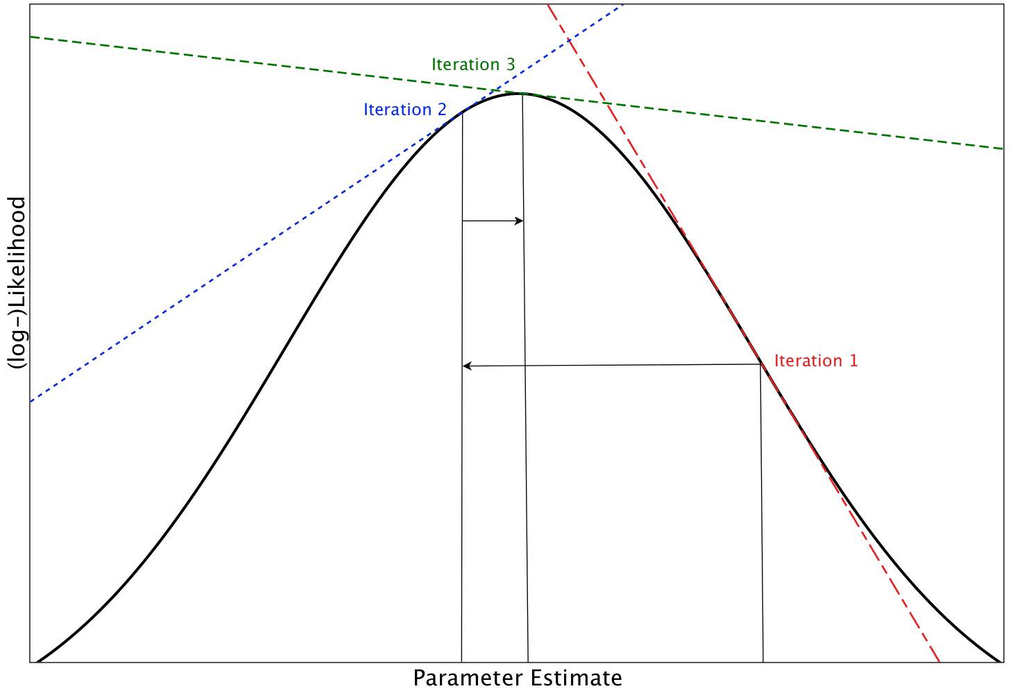

MLE

### Measures of Fit

##### Pseudo-$R^2$

In ML theory most interesting statistics are based on comparing likelihoods.

The Pseudo-$R^2$ of MacFadden is:
$$R^2 \equiv 1 -
\frac{l(\hat{\boldsymbol\beta})}{l_0(\bar{y})} \in [0,1]$$
where $l(\hat{\boldsymbol\beta})$ is the maximized log-likelihood and $l_0(\bar{y})$ is the constant only log-likelihood – the likelihood of the sample average.

We still use t-tests and F-tests (Wald tests), but they are essentially quadratic approximations of the curvature of the likelihood.

Likelihood ratio tests are more precise.

##### Liklihood ratio

AIC

$$= -2(lnL) + 2k$$
where L is the value of the likelihood, k is the number of estimated parameters

- it inclues penalty term for adding more independent variables

logliklihood function
$$l =
\frac{-n}{2}[1+ log(2\pi)+log\frac{\sum{\mu^2}}{n}]$$

BIC
$$= -2(lnL) + 2(lnN)k$$
where L is the value of the likelihood, N is the number of obs, k is the number of estimated parameters

### Odds Ratios

The output in the regression that is displayed to you are log odds ratios. To get the odds ratio, you just exponentiate the coefficients.

This is the relative odds of the occurrence of the outcome, given exposure to the variable. If it’s great than 1, higher odds, lower than 1, lower odds.

https://numiqo.com/tutorial/odds-ratio-logistic-regression

It’s much easier for us to understand the marginal effect of one unit and to do that, you need to take the first derivative with respect to your variable of interest! This is true for ANY regression. But because logit and probit are non-linear functional forms, the one unit change depends on the value.

### Estimating Partial Effects

What do we do with the estimates? Let $x_{j}$ be continuous.

In general, we can use the finite difference approach:
$$ME(X_i^b, X_i^a) = F(X_i^a) - F(X_i^b)$$
where $b$ and $a$ stand for before and after a change in $X_i$. In linear models, $F(\cdot)$ is by definition linear, so the outcome of $\Delta X_i = 1$ will be the slope or difference in means. With squares and interactions we need to be careful to change $X_i$ in more than one place, as a result $ME(X_i^b, X_i^a)$ will be non-constant.

Derivatives also give the partial effects (of a single regressor):
$$ME(X_i) = \frac{\partial}{\partial X_i}
F(\beta_0 + \beta_1 X_1 + \beta_2 X_2 + \dots + \beta_K
X_K)$$

which in OLS is (usually) just $\beta_k$ so we didn’t make a point of it. Not true if $F(\cdot)$ is non-linear.

Then the partial effect is

$$\begin{equation*}\frac{ \partial p
(\mathbf{x})}{ \partial x_{j}} =\beta _{j} g (\mathbf{x} \mathbf{\beta
})
\end{equation*}$$

where

$$g (z) =\exp (z)/[1 +\exp
(z)]^{2}$$
for logit

and, because $g (z) >0$, $\beta _{j}$ gives the direction of the partial effect. But its magnitude depends on $g (\mathbf{x} \mathbf{\beta })\text{.}$

For probit, the largest value of the scale factor is about $.4 =g (0)$. For logit, it is $g (0) =.25$.

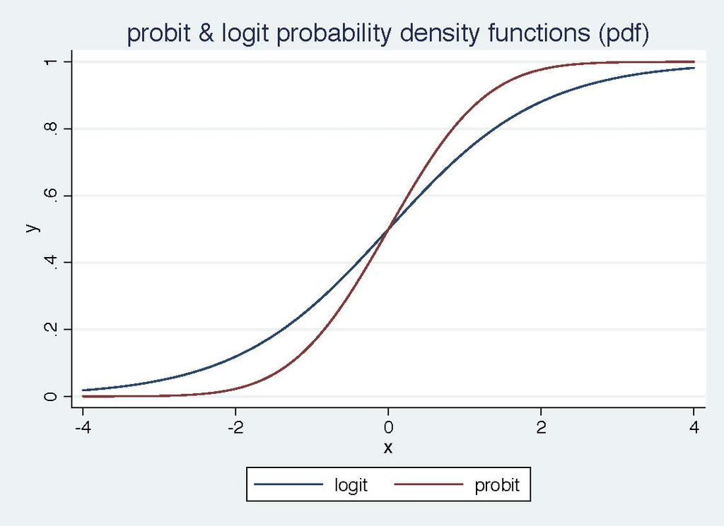

probit vs logit cdf

The $g ( \cdot )$ functions both have a bell shape and are maximized at zero. As $z \rightarrow \infty$, $g (z) \rightarrow 0$, which ensures that the partial effects head to zero for any $x_{j}$ with $\beta _{j} >0$.

For two continous covariates, the ratio of the coefficients give the ratio of the partial effects, independent of $\mathbf{x}$.

$$\begin{equation*}\frac{ \partial p
(\mathbf{x})/ \partial x_{j}}{ \partial p (\mathbf{x})/ \partial x_{h}}
=\frac{\beta _{j} g (\mathbf{x} \mathbf{\beta })}{\beta _{h} g
(\mathbf{x} \mathbf{\beta })} =\beta _{j}/\beta _{h}\text{.}
\end{equation*}$$

No simple relationship exists for discrete variables or changes.

In any case, we would like the magnitude of the effect.

Since these partial effects wrap a linear function, we use the chain rule ($\frac{dy}{dx} = \frac{dy}{du} \frac{du}{dx}$).

**Simple Probit**: $E[Y|X]= \text{Pr}(Y=1|X) = \Phi(\beta_0 + \beta_1 X_i)$

The marginal effect is $ME(X_i) = \beta_1 \times \phi(\beta_0 + \beta_1 X_i)$ and thus clearly varies with every $X_i$.

Note that the derivative of the normal cdf is $\Phi'(u) = \phi(u)$

**Simple Logit**: $E[Y|X]= \text{Pr}(Y=1|X) = \Lambda(\beta_0 + \beta_1 X_i)$

The marginal effect is $ME(X_i) = \beta_1 \times [\Lambda(\beta_0 + \beta_1 X_i)\Lambda(-\beta_0 - \beta_1 X_i)]$ or $ME(X_i) = \beta_1 \times [\Lambda(\beta_0 + \beta_1 X_i) - (1 - \Lambda(\beta_0 + \beta_1 X_i))]$ and thus clearly varies with every $X_i$.

Note that the derivative of the logistic cdf ($\Lambda(u)=1/(1+\exp(-u))$ is $\Lambda'(u) = \Lambda(u)\times (1 - \Lambda(u))$ but by symmetry of the cdf: $1 - \Lambda(u) = \Lambda(-u)$.

Since $ME(X_i)$ depends on the realization of $X$, we can easily envision two useful quantities: the estimated PEAs and APEs.

The estimated PEA for a continuous variable is:

$$\begin{equation*}\widehat{P E A}_{j}
=\hat{\beta }_{j} g (\bar{\mathbf{x}} \hat{\mathbf{\beta }})
\end{equation*}$$

As discussed earlier, putting in averages for discrete covariates might not be especially interesting.

When $x$ includes nonlinear functions, such as $age^{2}$, probably makes more sense to use $(\overline{age})^{2}$ rather than average $age_{i}^{2}$.

For example, you want the partial effect at the average of age where you have a non-linear function, $\beta_1 age_i + \beta_2 age_i^2$ If the average $\beta_1 age_i + \beta_2 age_i^2$

The APE has more appeal, as we are averaging partial effects for actual units:

$$\begin{equation*}\widehat{A P E}_{j}
=\hat{\beta }_{j} \left [N^{ -1} \sum _{i =1}^{N}g (\mathbf{x}_{i}
\hat{\mathbf{\beta }})\right ]
\end{equation*}$$

To use the delta method, must account for randomness in $\mathbf{x}_{i}$, too. Bootstrap makes that easy. Whether we use the PEA or APE, the scale factor multiplying $\hat{\beta }_{j}$ is below one, and sometimes well below one.

It makes no sense to compare magnitudes of coefficients across probit, logit, LPM. Comparing APEs is preferred.

In particular, if $\hat{\gamma }_{j}$ is the linear regression coefficient on $x_{j}$ from estimating an LPM, it can be compared with $\widehat{A P E}_{j}$ (provided no other function of $x_{j}$ appears in the regressors).

Suppose $x_{K}$ is a binary variable. Then its APE is estimated as

$$\begin{equation*}\widehat{A P E}_{K}
=N^{ -1} \sum _{i =1}^{N}[G(\mathbf{x}_{i (K)} \hat{\mathbf{\beta
}}_{(K)} +\hat{\beta }_{K}) -G (\mathbf{x}_{i (K)} \hat{\mathbf{\beta
}}_{(K)})]\text{,}
\end{equation*}$$
where $\mathbf{x}_{i (K)}$ is $\mathbf{x}_{i}$ but without $x_{i K}$.

The APE has a nice counterfactual interpretation that is especially useful in policy analysis - the *average treatment effect (ATE)* in the treatment effect literature with a binary outcome. (The “treatment”, $x_{K}$, is binary.) … we’ve heard about that.

Can average the individual treatment effects across subgroups, too, or insert fixed values for some of the other covariates.

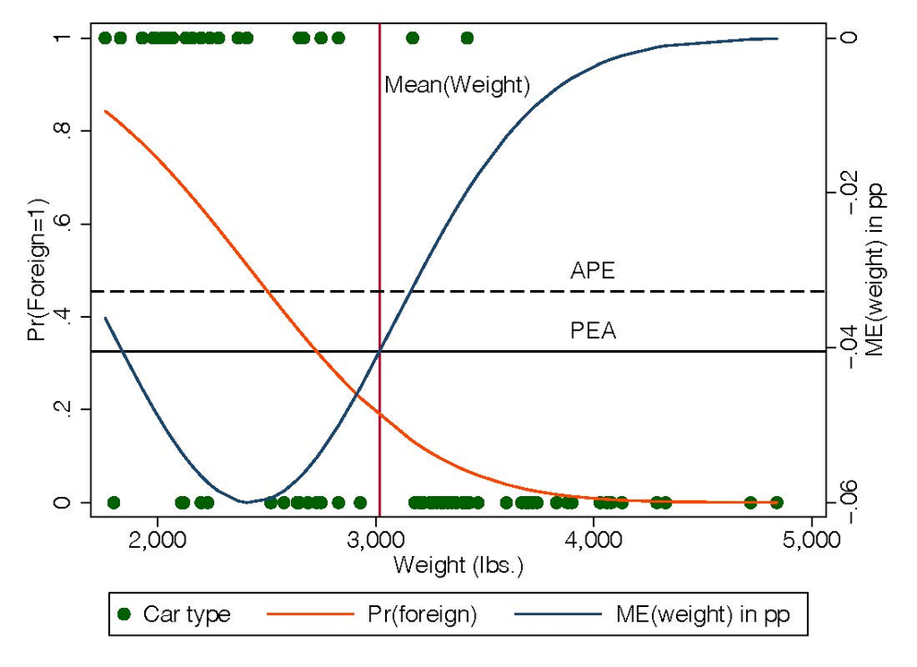

Because logit and probit use different probability functions, the coefficients (0,1) are different in the two models.

However, as suggested by the closeness of the graphs of the two CDFs, predicted probabilities will be very similar.

- Logit is relatively easy to calculate since it comes with an explicit, closed-form expression for the probability function.
- In probit, you have to numerically approximate an integral, which is much more arduous and used to be computationally expensive. This explains the historical popularity of the logit model. Computational ease is less important nowadays.
- There is a rough but good rule of thumb to predict the relative magnitudes of LPM, probit and logit coefficient estimates:

$$\beta_{Logit} \approx 1.6*\beta_{probit}
\approx 4* \beta_{LPM}$$

This is no magic, but the consequence of the different scalings implicit in the three models.

### Relating Average Partial Effects to Counterfactual Outcomes when $x_{k}$ is Binary

The APE estimates measures the difference in outcome probabilities for each person in both states (defined by $x_{k}$) of the world

For example, let $y$ be an employment indicator and $x_{k}$ be participation in a job training program.

With a probit or logit model, we are estimating the employment probability for each individual in both states of the world, regardless of whether the individual actually participated in the training program. Averaging the difference in estimated probabilities across individuals gives us the average treatment effect.

How it works:

We first estimate a logit or probit model that includes whether the individual received a grant along with controls

We then for each individual compute the estimated difference in probabilities of being employed uner the two scenarios that the person received a job training grant or did not.

Taking the average across each of these estimated difference gives us an estimate of the average treatment effect.

Including control variables like income, wealth, credit rating, age, etc. will hopefully control for all of the reasons that someone may or may not be approved for a loan that could also be related to race.

For a discrete $x_{K}$, the estimated PEA is

$$\begin{equation*}\widehat{P E A}_{K} =G
(\bar{\mathbf{x}}_{(K)} \hat{\mathbf{\beta }}_{(K)} +\hat{\beta }_{K})
-G (\bar{\mathbf{x}}_{(K)} \hat{\mathbf{\beta }}_{(K)})
\end{equation*}$$

Again, this might correspond to a weird population unit, or might not be representative of the population - so, generally, not very well advised.

Average treatment effect is much more useful (and is the same as the average partial effect)

##### Reporting the Results

- Start with an LPM and report the coefficients along with robust standard errors.
- With logit and probit, one typically reports the estimated coefficients along with standard errors. The value of the log likelihood is sometimes reported, too (as it can be used to compute tests of exclusion restrictions).
- It is important to report APEs and their standard errors for logit and probit (maybe even in place of coefficients). Sometimes a key policy variable is of interest, and it is important to estimate the magnitude of the effect.
- If the variable of interest is continuous, or at least takes on lots of values, might compute the partial effects at different values (and average out the other explanatory variables).

  ```
    - For example, in estimating the effects of young children on married women's labor force participation, we can estimate the partial effect in going from 0 to 1 and 1 to 2 children.
  ```

- Goodness-of-fit is not as important, but the percent correctly predicted for each outcome, and overall, is of some interest. Use $Pseudo-R^2$ or liklihood ratio.

Let’s try it.

Married Women’s Labor Force Participation (MROZ.DTA)

The variable $inlf$ is one if a woman worked for a wage during a certain year, and zero if not. We estimate a linear probability model to see the effects of variables on the probability of being in the labor force.

The package we are using is called glm.

As a reminder - we did this last semester in R and Python.

Let’s start with lpm

```r
library(wooldridge)
data("mroz")
library(car)
library(AER)
#recall this is just your ordinary ols estimation
lpm <- lm(inlf ~ nwifeinc +exper+ I(exper*exper)+motheduc+age+kidslt6+kidsge6, data =mroz )

lpm_robust <-coeftest(lpm, vcov = vcovHC, type = "HC0")
lpm_robust
```

```
##
## t test of coefficients:
##
##                     Estimate  Std. Error t value  Pr(>|t|)
## (Intercept)       0.90795455  0.13762423  6.5973 7.939e-11 ***
## nwifeinc         -0.00156986  0.00146929 -1.0684 0.2856657
## exper             0.04312458  0.00565930  7.6201 7.714e-14 ***
## I(exper * exper) -0.00066202  0.00018647 -3.5504 0.0004089 ***
## motheduc          0.01228209  0.00484294  2.5361 0.0114132 *
## age              -0.01678334  0.00241642 -6.9455 8.223e-12 ***
## kidslt6          -0.25252459  0.03228147 -7.8226 1.772e-14 ***
## kidsge6           0.00871206  0.01344520  0.6480 0.5172053
## ---
## Signif. codes:  0 '***' 0.001 '**' 0.01 '*' 0.05 '.' 0.1 ' ' 1
```

Compare to Probit

```r
probit <- glm(inlf ~nwifeinc +exper+ I(exper*exper)+motheduc+age+kidslt6+kidsge6, data =mroz, family = binomial(link = "probit"))

summary(probit)
```

```
##
## Call:
## glm(formula = inlf ~ nwifeinc + exper + I(exper * exper) + motheduc +
##     age + kidslt6 + kidsge6, family = binomial(link = "probit"),
##     data = mroz)
##
## Coefficients:
##                    Estimate Std. Error z value Pr(>|z|)
## (Intercept)       1.3604722  0.4499299   3.024 0.002497 **
## nwifeinc         -0.0054040  0.0045781  -1.180 0.237839
## exper             0.1299282  0.0184417   7.045 1.85e-12 ***
## I(exper * exper) -0.0019883  0.0005915  -3.362 0.000775 ***
## motheduc          0.0401333  0.0157308   2.551 0.010734 *
## age              -0.0536510  0.0084503  -6.349 2.17e-10 ***
## kidslt6          -0.8043145  0.1155390  -6.961 3.37e-12 ***
## kidsge6           0.0208533  0.0435382   0.479 0.631964
## ---
## Signif. codes:  0 '***' 0.001 '**' 0.01 '*' 0.05 '.' 0.1 ' ' 1
##
## (Dispersion parameter for binomial family taken to be 1)
##
##     Null deviance: 1029.75  on 752  degrees of freedom
## Residual deviance:  824.18  on 745  degrees of freedom
## AIC: 840.18
##
## Number of Fisher Scoring iterations: 4
```

And we need to get the marginal effects!

Logit:

```r
logit <- glm(inlf ~nwifeinc +exper+ I(exper*exper)+motheduc+age+kidslt6+kidsge6, data =mroz , family = "binomial")

summary(logit)
```

```
##
## Call:
## glm(formula = inlf ~ nwifeinc + exper + I(exper * exper) + motheduc +
##     age + kidslt6 + kidsge6, family = "binomial", data = mroz)
##
## Coefficients:
##                    Estimate Std. Error z value Pr(>|z|)
## (Intercept)       2.2519487  0.7607737   2.960  0.00308 **
## nwifeinc         -0.0096318  0.0077169  -1.248  0.21198
## exper             0.2169664  0.0314355   6.902 5.13e-12 ***
## I(exper * exper) -0.0033588  0.0009954  -3.374  0.00074 ***
## motheduc          0.0667126  0.0265687   2.511  0.01204 *
## age              -0.0888518  0.0145051  -6.126 9.04e-10 ***
## kidslt6          -1.3337837  0.1975992  -6.750 1.48e-11 ***
## kidsge6           0.0344206  0.0738017   0.466  0.64093
## ---
## Signif. codes:  0 '***' 0.001 '**' 0.01 '*' 0.05 '.' 0.1 ' ' 1
##
## (Dispersion parameter for binomial family taken to be 1)
##
##     Null deviance: 1029.75  on 752  degrees of freedom
## Residual deviance:  825.16  on 745  degrees of freedom
## AIC: 841.16
##
## Number of Fisher Scoring iterations: 4
```

Let’s check out the PEA and APE

```r
library(margins)

lpm_robust
```

```
##
## t test of coefficients:
##
##                     Estimate  Std. Error t value  Pr(>|t|)
## (Intercept)       0.90795455  0.13762423  6.5973 7.939e-11 ***
## nwifeinc         -0.00156986  0.00146929 -1.0684 0.2856657
## exper             0.04312458  0.00565930  7.6201 7.714e-14 ***
## I(exper * exper) -0.00066202  0.00018647 -3.5504 0.0004089 ***
## motheduc          0.01228209  0.00484294  2.5361 0.0114132 *
## age              -0.01678334  0.00241642 -6.9455 8.223e-12 ***
## kidslt6          -0.25252459  0.03228147 -7.8226 1.772e-14 ***
## kidsge6           0.00871206  0.01344520  0.6480 0.5172053
## ---
## Signif. codes:  0 '***' 0.001 '**' 0.01 '*' 0.05 '.' 0.1 ' ' 1
```

```r
#calculate average marginal effects
logit_m <-margins(logit)
summary(logit_m)
```

|  | factor | AME | SE | z | p | lower | upper |
| --- | --- | --- | --- | --- | --- | --- | --- |
| 1 | age | -0.016368054 | 0.002438926 | -6.7111731 | 1.930659e-11 | -0.021148261 | -0.011587847 |
| 2 | exper | 0.027557462 | 0.002172788 | 12.6829952 | 7.346974e-37 | 0.023298875 | 0.031816048 |
| 3 | kidsge6 | 0.006340885 | 0.013586892 | 0.4666914 | 6.407207e-01 | -0.020288934 | 0.032970704 |
| 4 | kidslt6 | -0.245706261 | 0.032404362 | -7.5825057 | 3.389442e-14 | -0.309217644 | -0.182194878 |
| 5 | motheduc | 0.012289636 | 0.004824591 | 2.5472905 | 1.085630e-02 | 0.002833611 | 0.021745661 |
| 6 | nwifeinc | -0.001774337 | 0.001416837 | -1.2523232 | 2.104521e-01 | -0.004551286 | 0.001002611 |

```r
probit_m <-margins(probit)
summary(probit_m)
```

|  | factor | AME | SE | z | p | lower | upper |
| --- | --- | --- | --- | --- | --- | --- | --- |
| 1 | age | -0.016583187 | 0.002414329 | -6.8686537 | 6.481062e-12 | -0.021315184 | -0.011851190 |
| 2 | exper | 0.027734102 | 0.002171564 | 12.7714897 | 2.365828e-37 | 0.023477915 | 0.031990288 |
| 3 | kidsge6 | 0.006445609 | 0.013450476 | 0.4792105 | 6.317889e-01 | -0.019916839 | 0.032808057 |
| 4 | kidslt6 | -0.248608428 | 0.032375117 | -7.6789969 | 1.603391e-14 | -0.312062492 | -0.185154364 |
| 5 | motheduc | 0.012404935 | 0.004804555 | 2.5819112 | 9.825487e-03 | 0.002988180 | 0.021821690 |
| 6 | nwifeinc | -0.001670332 | 0.001411617 | -1.1832752 | 2.367001e-01 | -0.004437051 | 0.001096387 |

```r
#calculate PEA

lpm_robust
```

```
##
## t test of coefficients:
##
##                     Estimate  Std. Error t value  Pr(>|t|)
## (Intercept)       0.90795455  0.13762423  6.5973 7.939e-11 ***
## nwifeinc         -0.00156986  0.00146929 -1.0684 0.2856657
## exper             0.04312458  0.00565930  7.6201 7.714e-14 ***
## I(exper * exper) -0.00066202  0.00018647 -3.5504 0.0004089 ***
## motheduc          0.01228209  0.00484294  2.5361 0.0114132 *
## age              -0.01678334  0.00241642 -6.9455 8.223e-12 ***
## kidslt6          -0.25252459  0.03228147 -7.8226 1.772e-14 ***
## kidsge6           0.00871206  0.01344520  0.6480 0.5172053
## ---
## Signif. codes:  0 '***' 0.001 '**' 0.01 '*' 0.05 '.' 0.1 ' ' 1
```

```r
margins(logit, at = list(motheduc = c(mean(mroz$motheduc, na.rm=TRUE))), variables = "motheduc")
```

[output not shown]

[output cut: 743 more lines]

```r
margins(probit, at = list(motheduc = c(mean(mroz$motheduc, na.rm=TRUE))), variables = "motheduc")
```

[output not shown]

[output cut: 743 more lines]

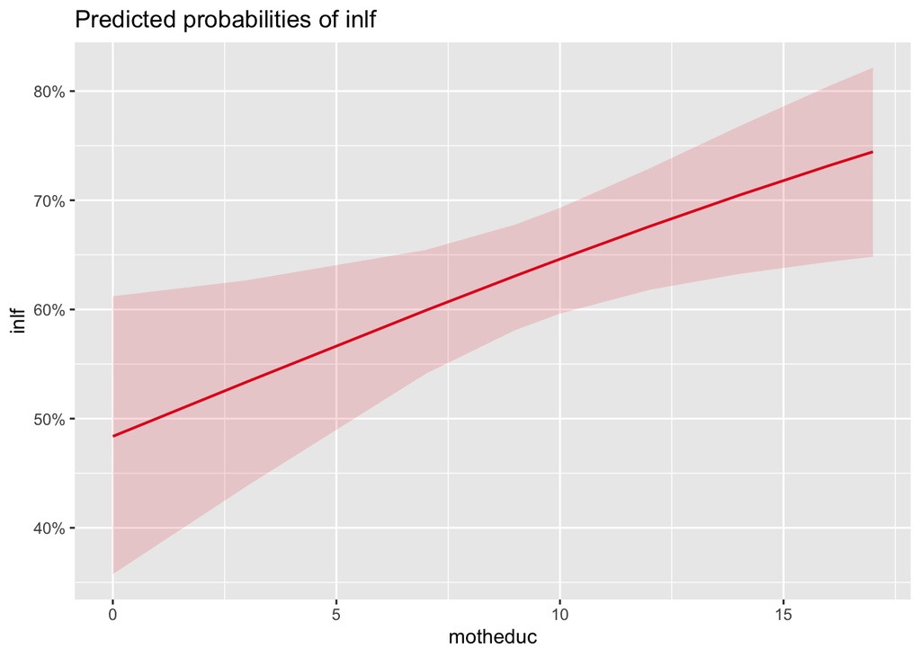

```r
library(sjPlot)
library(ggplot2)

#here's educ
plot_model(logit, type = "eff", terms = "motheduc")
```

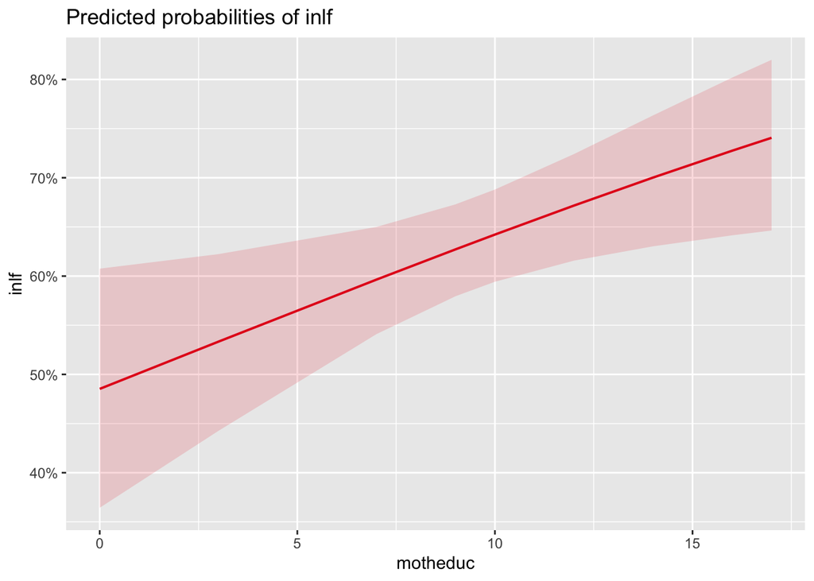

```r
plot_model(probit, type = "eff", terms = "motheduc")
```

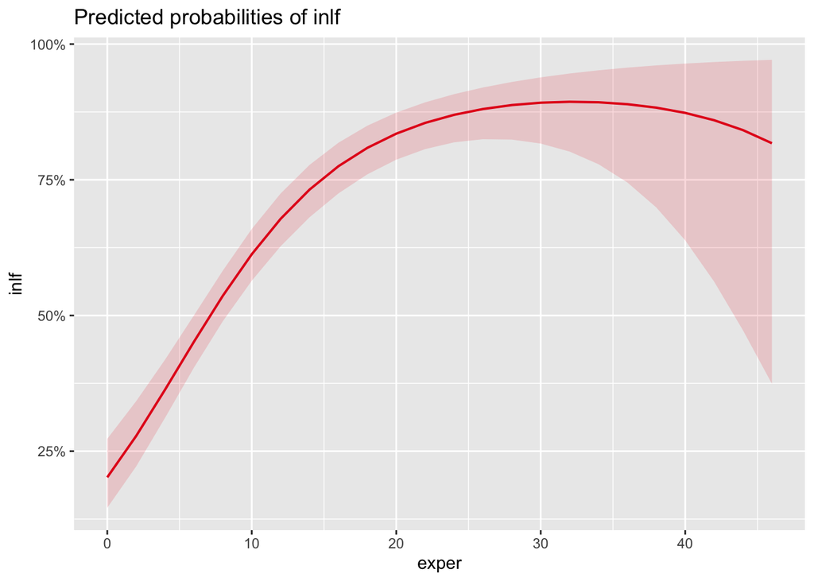

```r
#here's experience (and note that this is a squared term)
plot_model(logit, type = "eff", terms = "exper")
```

We can also do Logit and Probit in a panel data setting.

```r
library(foreign) #this let's you import stata data directly into R

#union <- read.dta("http://data.princeton.edu/wws509/datasets/union.dta")
#fe <- clogit(union ~ age + grade + not_smsa + south + southXt + strata(idcode), data = union)
```

And for fun, enjoy this meme:

[figure not shown]

What is superior